# QTM 350 - Data Science Computing

Lecture 14 - Introduction to Pandas

Danilo Freire

danilo.freire@emory.edu

Emory University

# Hello, everyone! 👋

# I’ve made something! Let me know if it works 🐍

## Jupyter Notebooks online 🌐

- New users find it challenging to install Python and Jupyter Notebook on their computers
- So I’ve made a Jupyter Notebook online that you can use to run Python code without installing anything! 🤓
- I’ve used [Pyodide](https://pyodide.org/en/stable/) and [JupyterLite](https://jupyterlite.readthedocs.io/) to run Python code in the browser
- You can access it on the [Jupyter Lite tab on the course website](https://danilofreire.github.io/qtm350/)
- The website is https://danilofreire.github.io/qtm350/jupyter
- It already comes with all packages we need for this class, such as NumPy, Pandas, Matplotlib, and Seaborn
- You can install many other packages too! 📦
- Not all Python packages work, but many do. Install them with

```python
%pip install package-name
```

- You can also use it to run `R` and `JavaScript` code, as well as write `LaTeX` and `Markdown` documents
- Please download your files with the right-click menu before closing the browser!
- Let me know if you find any bugs! 🐞

# Brief recap of the last lecture

## Introduction to Python 🐍

- In the last lecture, we had a brief introduction to Python
- We covered the main concepts of the language, such as variables, operators, control structures, and functions
- We also saw how to install Python and Jupyter Notebook
- We briefly discussed the various data types in Python, such as integers, floats, strings, lists, tuples, and dictionaries
- We finished with for loops, if statements, and functions
- Today we will see lean more about [Numpy](https://numpy.org) and, more importantly, [Pandas](https://pandas.pydata.org/)

[figure not shown]

[figure not shown]

# Numpy 🧮

## Numpy arrays

#### What is Numpy?

```python
import numpy as np
```

#### What is an array?

- Arrays are “n-dimensional” data structures that can contain all the basic Python data types, e.g., floats, integers, strings etc
- However, they work best with numeric data
- NumPy arrays (`ndarrays`) are homogenous, which means that items in the array should be of the same type.
- `ndarrays` are also compatible with numpy’s vast collection of in-built functions!

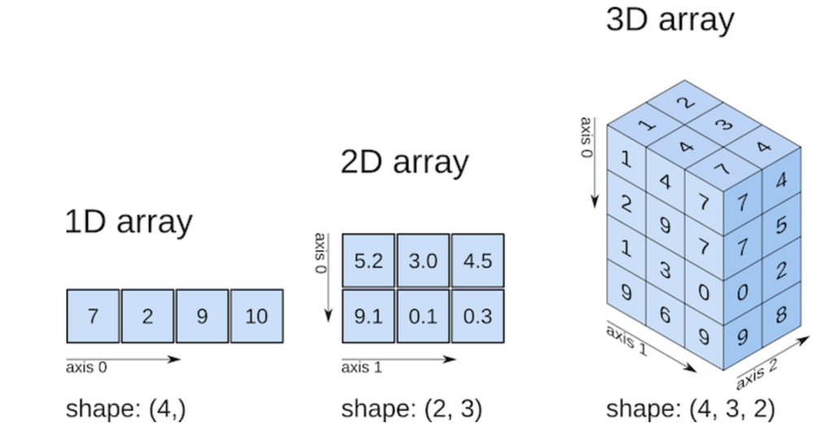

## Creating arrays

- A numpy array is sort of like a list, but with more functionality

```python
my_list = [1, 2, 3, 4, 5]
my_list
```

```
[1, 2, 3, 4, 5]
```

```python
my_array = np.array([1, 2, 3, 4, 5])
my_array
```

```
array([1, 2, 3, 4, 5])
```

- But it has the type `numpy.ndarray`
- Unlike a list, arrays can only hold a single type (usually numbers). Check this out

```python
my_list = [1, "hi"]
my_list
```

```
[1, 'hi']
```

```python
my_array = np.array([1, "hi"])
my_array
```

```
array(['1', 'hi'], dtype='<U21')
```

- Above: NumPy converted the integer 1 into the string `'1'`!
- `ndarrays` are typically created using two main methods:
  - From existing data using `np.array()`
  - Using built-in functions like `np.zeros()`, `np.ones()`, `np.arange()`, `np.linspace()`, `np.random.normal()`, etc.
- Let’s see some examples

```python
my_list = [1, 2, 3]
np.array(my_list)
```

```
array([1, 2, 3])
```

```python
np.arange(1, 10, 2)  # from 1 inclusive to 10 exclusive, step 2
```

```
array([1, 3, 5, 7, 9])
```

```python
np.linspace(0, 10, 5) # from 0 to 10, 5 numbers
```

```
array([ 0. ,  2.5,  5. ,  7.5, 10. ])
```

- You can have multi-dimensional arrays (indicated by double square brackets `[[ ]]`):

```python
np.array([[1, 2, 3], [4, 5, 6]])
```

```
array([[1, 2, 3],
       [4, 5, 6]])
```

## Array operations

- Arrays can be used in arithmetic operations, such as addition, subtraction, multiplication, and division
- These operations are performed element-wise, meaning that the operation is applied to each element in the array

```python
a = np.array([1, 2, 3])
b = np.array([4, 5, 6])
a + b
```

```
array([5, 7, 9])
```

```python
a * b
```

```
array([ 4, 10, 18])
```

- You can also apply functions to arrays, such as `np.sqrt()`, `np.exp()`, `np.log()`, `np.sin()`, `np.cos()`, `np.tan()`, etc. Please check the [documentation](https://numpy.org/doc/stable/reference/arrays.ndarray.html#array-methods) for more information

```python
np.sqrt(a)
```

```
array([1.        , 1.41421356, 1.73205081])
```

```python
np.exp(a)
```

```
array([ 2.71828183,  7.3890561 , 20.08553692])
```

- You can also apply logical operations to arrays, such as `==`, `!=`, `>`, `<`, `>=`, `<=`, etc.
- These operations return boolean arrays

```python
a == b
```

```
array([False, False, False])
```

```python
a < b
```

```
array([ True,  True,  True])
```

- You can call (most of) these functions on the array itself using the [dot notation](https://builtin.com/data-science/dot-notation) `a.sum()`, `a.mean()`, `a.max()`, `a.min()`, etc.
  - A dot “.” basically means “in here”

```python
a.sum()
```

```
6
```

```python
a.mean()
```

```
2.0
```

```python
a.max()
```

```
3
```

## Broadcasting

- Broadcasting allows NumPy to work with arrays of different shapes when performing arithmetic operations
- The smaller array is “broadcast” across the larger array so that they have compatible shapes
- So it substitues `for` loops in many cases! 😅
- One example is adding a scalar to an array

```python
cost = np.array([20, 15, 25])
print("Pie cost:")
print(cost)
```

```
Pie cost:
[20 15 25]
```

```python
sales = np.array([[2, 3, 1], [6, 3, 3], [5, 3, 5]])
print("\nPie sales (#):")
print(sales)
```

```
Pie sales (#):
[[2 3 1]
 [6 3 3]
 [5 3 5]]
```

- How do we make them the same size?

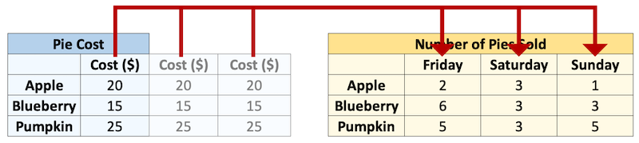

- We can broadcast the cost array to the sales array
- We will use the `np.repeat()` function to do this

```python
cost = np.repeat(cost, 3).reshape((3, 3))
cost
```

```
array([[20, 20, 20],
       [15, 15, 15],
       [25, 25, 25]])
```

- Now we can calculate the total sales

```python
total_sales = cost * sales
total_sales
```

```
array([[ 40,  60,  20],
       [ 90,  45,  45],
       [125,  75, 125]])
```

- Wohoo! 🥳 Much easier than creating a loop

## Indexing and slicing

#### Numeric indexing

- Indexing arrays is similar to indexing lists but there are just more dimensions
- We use square brackets `[]` to index arrays
- Colons `:` are used to slice arrays

```python
x = np.arange(10)
x
```

```
array([0, 1, 2, 3, 4, 5, 6, 7, 8, 9])
```

```python
x[3]
```

```
3
```

```python
x[2:5]
```

```
array([2, 3, 4])
```

```python
x[2:]
```

```
array([2, 3, 4, 5, 6, 7, 8, 9])
```

```python
x[-1]
```

```
9
```

```python
x[5:0:-1] # reverse
```

```
array([5, 4, 3, 2, 1])
```

#### Multi-dimensional arrays

- For multi-dimensional arrays, we use commas to separate the indices
- The first index refers to the row, the second to the column, and so on

```python
x = np.random.randint(10, size=(4, 6))
x
```

```
array([[9, 4, 7, 9, 4, 4],
       [7, 6, 3, 2, 1, 1],
       [6, 7, 6, 0, 5, 3],
       [1, 3, 1, 7, 8, 1]])
```

```python
x[3, 4]
```

```
8
```

```python
x[2, :]
```

```
array([6, 7, 6, 0, 5, 3])
```

```python
x[:, 3]
```

```
array([9, 2, 0, 7])
```

```python
x[2:, :3]
```

```
array([[6, 7, 6],
       [1, 3, 1]])
```

# Pandas! 🐼

## Pandas is pretty cool! 🐼

### Pandas Series

- Pandas is the most popular Python library for tabular data structures
- Think of Pandas as an extremely powerful version of Excel or `dplyr` + `tibble` in `R`
- Pandas is built on top of NumPy, so it is fast and memory efficient
- Pandas has two main data structures: `Series` and `DataFrame`
- A `Series` is a one-dimensional array with an index, pretty much like a `np.array`, but with a label for each element
  - They are strictly one-dimensional
- You can create a `Series` from a list, a NumPy array, a dictionary, or a scalar value using `pd.Series()` (note the capital “S”)
- You import pandas with `import pandas as pd`

## Creating Series

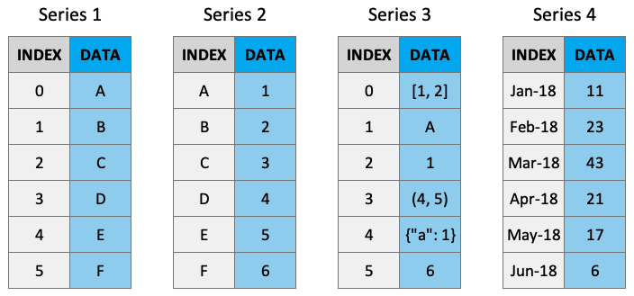

```python
import pandas as pd

pd.Series(data = [-5, 1.3, 21, 6, 3])
```

```
0    -5.0
1     1.3
2    21.0
3     6.0
4     3.0
dtype: float64
```

- The left column is the index, and the right column is the data
- If you don’t specify an index, Pandas will create one for you
- But you can add a custom index:

```python
pd.Series(data = [-5, 1.3, 21, 6, 3],
          index = ['a', 'b', 'c', 'd', 'e'])
```

```
a    -5.0
b     1.3
c    21.0
d     6.0
e     3.0
dtype: float64
```

- You can create a Series from a dictionary:

```python
pd.Series(data = {'a': 10, 'b': 20, 'c': 30})
```

```
a    10
b    20
c    30
dtype: int64
```

## Indexing and slicing Series

- You can index and slice a `Series` like a NumPy array
- In fact, series can be passed to most NumPy functions!
- They can be indexed using square brackets `[ ]` and sliced using colon `:` notation:

```python
s = pd.Series(data = range(5),
              index = ['A', 'B', 'C', 'D', 'E'])
s
```

```
A    0
B    1
C    2
D    3
E    4
dtype: int64
```

```python
s[0]
```

```
0
```

```python
s['A']
```

```
0
```

```python
s[["B", "D", "C"]]
```

```
B    1
D    3
C    2
dtype: int64
```

- Note above how array-based indexing and slicing also returns the series index
- Finally, we can also do boolean indexing with series

```python
s[s >= 1]
```

```
B    1
C    2
D    3
E    4
dtype: int64
```

```python
s[s > s.mean()]
```

```
D    3
E    4
dtype: int64
```

```python
(s != 1)
```

```
A     True
B    False
C     True
D     True
E     True
dtype: bool
```

## Series operations

- Series can be used in arithmetic operations, such as addition, subtraction, multiplication, and division
- Unlike `ndarrays`, operations between Series align values based on their LABELS (not their position in the structure)
- The resulting index will be the sorted union of the two indexes

```python
s1 = pd.Series(data = range(4),
               index = ["A", "B", "C", "D"])
s1
```

```
A    0
B    1
C    2
D    3
dtype: int64
```

```python
s2 = pd.Series(data = range(10, 14),
               index = ["B", "C", "D", "E"])
s2
```

```
B    10
C    11
D    12
E    13
dtype: int64
```

```python
s1 + s2
```

```
A     NaN
B    11.0
C    13.0
D    15.0
E     NaN
dtype: float64
```

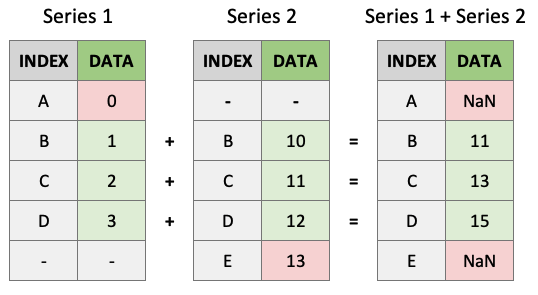

- Indices that don’t match will appear in the product but with NaN values
- NumPy also accepts series as an argument to most functions because series are built off numpy arrays

```python
np.exp(s1)
```

```
A     1.000000
B     2.718282
C     7.389056
D    20.085537
dtype: float64
```

# Pandas DataFrames 🐼

## Pandas DataFrames

- Pandas DataFrames are your new best friend 😂
- DataFrames are really just Series stuck together!
- Think of a DataFrame as a dictionary of series, with the “keys” being the column labels and the “values” being the series data

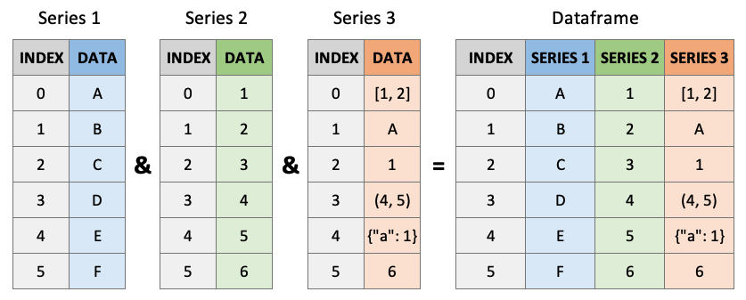

- Dataframes can be created using `pd.DataFrame()` (note the capital “D” and “F”)

```python
pd.DataFrame([[1, 2, 3],
              [4, 5, 6],
              [7, 8, 9]])
```

|  | 0 | 1 | 2 |
| --- | --- | --- | --- |
| 0 | 1 | 2 | 3 |
| 1 | 4 | 5 | 6 |
| 2 | 7 | 8 | 9 |

- We can use the `index` and `columns` arguments to give them labels:

```python
pd.DataFrame([[1, 2, 3],
              [4, 5, 6],
              [7, 8, 9]],
             index = ["R1", "R2", "R3"],
             columns = ["C1", "C2", "C3"])
```

|  | C1 | C2 | C3 |
| --- | --- | --- | --- |
| R1 | 1 | 2 | 3 |
| R2 | 4 | 5 | 6 |
| R3 | 7 | 8 | 9 |

## Creating DataFrames

- DataFrames can be created from dictionaries, lists, NumPy arrays, and Series
- It is common to create DataFrames from dictionaries, where the keys are the column names and the values are the data

```python
pd.DataFrame({"C1": [1, 2, 3],
              "C2": ['A', 'B', 'C']},
             index=["R1", "R2", "R3"])
```

|  | C1 | C2 |
| --- | --- | --- |
| R1 | 1 | A |
| R2 | 2 | B |
| R3 | 3 | C |

- Usually, you will create a `DataFrame` from a CSV file using `pd.read_csv()`
- You can also create a `DataFrame` from an Excel file using `pd.read_excel()`
- Pandas can read from many other sources, such as SQL databases (as we will see in this course), JSON files, and even HTML tables

```python
df = pd.read_csv("data/iris.csv")
df.head()
```

|  | sepal_length | sepal_width | petal_length | petal_width | species |
| --- | --- | --- | --- | --- | --- |
| 0 | 5.1 | 3.5 | 1.4 | 0.2 | Iris-setosa |
| 1 | 4.9 | 3.0 | 1.4 | 0.2 | Iris-setosa |
| 2 | 4.7 | 3.2 | 1.3 | 0.2 | Iris-setosa |
| 3 | 4.6 | 3.1 | 1.5 | 0.2 | Iris-setosa |
| 4 | 5.0 | 3.6 | 1.4 | 0.2 | Iris-setosa |

## Creating DataFrames - Cheat Sheet

| Create DataFrame from | Code |
| --- | --- |
| Lists of lists | `pd.DataFrame([['Danilo', 7], ['Maria', 15], ['Lucas', 3]])` |
| ndarray | `pd.DataFrame(np.array([['Danilo', 7], ['Maria', 15], ['Lucas', 3]]))` |
| Dictionary | `pd.DataFrame({"Name": ['Danilo', 'Maria', 'Lucas'], "Number": [7, 15, 3]})` |
| List of tuples | `pd.DataFrame(zip(['Danilo', 'Maria', 'Lucas'], [7, 15, 3]))` |
| Series | `pd.DataFrame({"Name": pd.Series(['Danilo', 'Maria', 'Lucas']), "Number": pd.Series([7, 15, 3])})` |

See the [Pandas documentation](https://pandas.pydata.org/pandas-docs/stable/user_guide/dsintro.html#dataframe) for more

## Indexing and slicing DataFrames

- There are several main ways to select data from a DataFrame:
  - Using square brackets `[ ]`, `.loc[]`, `.iloc[]`, Boolean indices, and `.query()`

```python
df = pd.DataFrame({"Name": ["Danilo", "Maria", "Lucas"],
                   "Language": ["Python", "Python", "R"],
                   "Courses": [5, 4, 7]})
df
```

|  | Name | Language | Courses |
| --- | --- | --- | --- |
| 0 | Danilo | Python | 5 |
| 1 | Maria | Python | 4 |
| 2 | Lucas | R | 7 |

- You can select a column using square brackets `[ ]` or dot notation `.`

```python
df["Name"]
```

```
0    Danilo
1     Maria
2     Lucas
Name: Name, dtype: object
```

```python
df.Name
```

```
0    Danilo
1     Maria
2     Lucas
Name: Name, dtype: object
```

- You can select multiple columns by passing a list of column names

```python
df[["Name", "Courses"]]
```

|  | Name | Courses |
| --- | --- | --- |
| 0 | Danilo | 5 |
| 1 | Maria | 4 |
| 2 | Lucas | 7 |

- You can select rows using `.iloc[]`, which accepts integers as references to rows/columns

```python
df.iloc[0]  # returns a series
```

```
Name        Danilo
Language    Python
Courses          5
Name: 0, dtype: object
```

```python
df.iloc[0:2]  # returns a dataframe
```

|  | Name | Language | Courses |
| --- | --- | --- | --- |
| 0 | Danilo | Python | 5 |
| 1 | Maria | Python | 4 |

## Indexing and slicing DataFrames

- Now let’s look at `.loc` which accepts labels as references to rows/columns:

```python
df.loc[:, 'Name']
```

```
0    Danilo
1     Maria
2     Lucas
Name: Name, dtype: object
```

```python
df.loc[:, 'Name':'Language']
```

|  | Name | Language |
| --- | --- | --- |
| 0 | Danilo | Python |
| 1 | Maria | Python |
| 2 | Lucas | R |

```python
df.loc[[0, 2], ['Language']]
```

|  | Language |
| --- | --- |
| 0 | Python |
| 2 | R |

- Boolean indexing is also possible

```python
df[df["Courses"] > 5]
```

|  | Name | Language | Courses |
| --- | --- | --- | --- |
| 2 | Lucas | R | 7 |

```python
df[df['Name'] == "Danilo"]
```

|  | Name | Language | Courses |
| --- | --- | --- | --- |
| 0 | Danilo | Python | 5 |

## Indexing and slicing with `.query()`

- The `.query()` method allows you to select data using a string expression
- It is my favourite method because it is more readable and less error-prone
- `.query()` accepts a string expression to evaluate and it “knows” the names of the columns in your dataframe

```python
df.query('Courses > 5')
```

|  | Name | Language | Courses |
| --- | --- | --- | --- |
| 2 | Lucas | R | 7 |

```python
df.query('Name == "Danilo"')
```

|  | Name | Language | Courses |
| --- | --- | --- | --- |
| 0 | Danilo | Python | 5 |

```python
df.query("Courses > 4 & Language == 'Python'")
```

|  | Name | Language | Courses |
| --- | --- | --- | --- |
| 0 | Danilo | Python | 5 |

- Note the use of single quotes AND double quotes above, lucky we have both in Python!
- You can also use the `@` symbol to reference variables in the environment

```python
min_courses = 5
df.query("Courses > @min_courses")
```

|  | Name | Language | Courses |
| --- | --- | --- | --- |
| 2 | Lucas | R | 7 |

## Indexing cheatsheet

| Method | Syntax | Output |
| --- | --- | --- |
| Select column | `df[col_label]` | Series |
| Select row slice | `df[row_1_int:row_2_int]` | DataFrame |
| Select row/column by label | `df.loc[row_label(s), col_label(s)]` | Object for single selection, Series for one row/column, otherwise DataFrame |
| Select row/column by integer | `df.iloc[row_int(s), col_int(s)]` | Object for single selection, Series for one row/column, otherwise DataFrame |
| Select by row integer & column label | `df.loc[df.index[row_int], col_label]` | Object for single selection, Series for one row/column, otherwise DataFrame |
| Select by row label & column integer | `df.loc[row_label, df.columns[col_int]]` | Object for single selection, Series for one row/column, otherwise DataFrame |
| Select by boolean | `df[bool_vec]` | Object for single selection, Series for one row/column, otherwise DataFrame |
| Select by boolean expression | `df.query("expression")` | Object for single selection, Series for one row/column, otherwise DataFrame |

# Reading/Writing Data From External Sources 📂

## Reading data from external sources

#### .csv files

- Pandas can read data from many sources, such as CSV, Excel, SQL databases, JSON, HTML, and more
- As mentioned above, `.csv` files are the most common data format (for good reason!)
- You can use the `pd.read_csv()` function for this
- There are so many arguments that can be used to help read in your `.csv` file in an efficient and appropriate manner, feel free to check them out by using `shift + tab` in Jupyter, or typing `help(pd.read_csv)`

[output not shown]

- You can save a DataFrame to a `.csv` file using `df.to_csv()`

```python
df.to_csv("data/iris_copy.csv", index=False)
```

#### URLs

- You can also read data from a URL using `pd.read_csv()`
- This is useful when you want to read data from a website without downloading it first

```python
url = "https://github.com/danilofreire/qtm350/raw/refs/heads/main/lectures/lecture-14/data/iris.csv"
df = pd.read_csv(url)
df.head()
```

|  | sepal_length | sepal_width | petal_length | petal_width | species |
| --- | --- | --- | --- | --- | --- |
| 0 | 5.1 | 3.5 | 1.4 | 0.2 | Iris-setosa |
| 1 | 4.9 | 3.0 | 1.4 | 0.2 | Iris-setosa |
| 2 | 4.7 | 3.2 | 1.3 | 0.2 | Iris-setosa |
| 3 | 4.6 | 3.1 | 1.5 | 0.2 | Iris-setosa |
| 4 | 5.0 | 3.6 | 1.4 | 0.2 | Iris-setosa |

- See the [Pandas documentation here](https://pandas.pydata.org/pandas-docs/stable/user_guide/io.html#io-tools-text-csv-hdf5) for information about reading and writing data

# Common DataFrame Operations 🐼

## Common DataFrame operations

- DataFrames have built-in functions for performing most common operations, e.g., `.min()`, `idxmin()`, `sort_values()`, etc.
- They’re all documented in the [Pandas documentation here](https://pandas.pydata.org/pandas-docs/stable/reference/api/pandas.DataFrame.html) but I’ll demonstrate a few below

```python
df = pd.read_csv('data/cycling_data.csv')
df.head(7)
```

|  | Date | Name | Type | Time | Distance | Comments |
| --- | --- | --- | --- | --- | --- | --- |
| 0 | 10 Sep 2019, 00:13:04 | Afternoon Ride | Ride | 2084 | 12.62 | Rain |
| 1 | 10 Sep 2019, 13:52:18 | Morning Ride | Ride | 2531 | 13.03 | rain |
| 2 | 11 Sep 2019, 00:23:50 | Afternoon Ride | Ride | 1863 | 12.52 | Wet road but nice weather |
| 3 | 11 Sep 2019, 14:06:19 | Morning Ride | Ride | 2192 | 12.84 | Stopped for photo of sunrise |
| 4 | 12 Sep 2019, 00:28:05 | Afternoon Ride | Ride | 1891 | 12.48 | Tired by the end of the week |
| 5 | 16 Sep 2019, 13:57:48 | Morning Ride | Ride | 2272 | 12.45 | Rested after the weekend! |
| 6 | 17 Sep 2019, 00:15:47 | Afternoon Ride | Ride | 1973 | 12.45 | Legs feeling strong! |

```python
df.min()
```

```
Date                         1 Oct 2019, 00:15:07
Name                               Afternoon Ride
Type                                         Ride
Time                                         1712
Distance                                    11.79
Comments    A little tired today but good weather
dtype: object
```

```python
df['Time'].min()
```

```
1712
```

```python
df['Time'].idxmin() # index of the minimum value
```

```
20
```

```python
df.iloc[20]
```

```
Date               27 Sep 2019, 01:00:18
Name                      Afternoon Ride
Type                                Ride
Time                                1712
Distance                           12.47
Comments    Tired by the end of the week
Name: 20, dtype: object
```

## Sorting DataFrames

- `.sort_values()` is used to sort a DataFrame by one or more columns
- You can sort by one or more columns, and you can specify the order (ascending or descending)
- The default argument is `ascending=True`

```python
df.sort_values(by='Distance').head()
```

|  | Date | Name | Type | Time | Distance | Comments |
| --- | --- | --- | --- | --- | --- | --- |
| 32 | 11 Oct 2019, 00:16:57 | Afternoon Ride | Ride | 1843 | 11.79 | Bike feeling tight, needs an oil and pump |
| 16 | 25 Sep 2019, 00:07:21 | Afternoon Ride | Ride | 1775 | 12.10 | Feeling really tired |
| 5 | 16 Sep 2019, 13:57:48 | Morning Ride | Ride | 2272 | 12.45 | Rested after the weekend! |
| 6 | 17 Sep 2019, 00:15:47 | Afternoon Ride | Ride | 1973 | 12.45 | Legs feeling strong! |
| 20 | 27 Sep 2019, 01:00:18 | Afternoon Ride | Ride | 1712 | 12.47 | Tired by the end of the week |

```python
df.sort_values(by='Distance', ascending=False).head(4)
```

|  | Date | Name | Type | Time | Distance | Comments |
| --- | --- | --- | --- | --- | --- | --- |
| 8 | 18 Sep 2019, 13:49:53 | Morning Ride | Ride | 2903 | 14.57 | Raining today |
| 25 | 2 Oct 2019, 13:46:06 | Morning Ride | Ride | 2134 | 13.06 | Bit tired today but good weather |
| 1 | 10 Sep 2019, 13:52:18 | Morning Ride | Ride | 2531 | 13.03 | rain |
| 19 | 26 Sep 2019, 13:42:43 | Morning Ride | Ride | 2350 | 12.91 | Detour around trucks at Jericho |

- You can also combine `.query()` with `.sort_values()`

```python
df.query('Distance > 13').sort_values(by='Time')
```

|  | Date | Name | Type | Time | Distance | Comments |
| --- | --- | --- | --- | --- | --- | --- |
| 25 | 2 Oct 2019, 13:46:06 | Morning Ride | Ride | 2134 | 13.06 | Bit tired today but good weather |
| 1 | 10 Sep 2019, 13:52:18 | Morning Ride | Ride | 2531 | 13.03 | rain |
| 8 | 18 Sep 2019, 13:49:53 | Morning Ride | Ride | 2903 | 14.57 | Raining today |

# DataFrame Characteristics 🔎

## DataFrame characteristics

- DataFrames have many attributes that can be used to understand the data
- For example, you can use `.shape` to get the dimensions of the DataFrame

```python
df.shape
```

```
(33, 6)
```

- `.info()` prints a summary of the DataFrame

```python
df.info()
```

```
<class 'pandas.core.frame.DataFrame'>
RangeIndex: 33 entries, 0 to 32
Data columns (total 6 columns):
 #   Column    Non-Null Count  Dtype
---  ------    --------------  -----
 0   Date      33 non-null     object
 1   Name      33 non-null     object
 2   Type      33 non-null     object
 3   Time      33 non-null     int64
 4   Distance  31 non-null     float64
 5   Comments  33 non-null     object
dtypes: float64(1), int64(1), object(4)
memory usage: 1.7+ KB
```

- `.columns` returns the column names

```python
df.columns
```

```
Index(['Date', 'Name', 'Type', 'Time', 'Distance', 'Comments'], dtype='object')
```

- `.describe()` prints the descriptive stats of the numerical columns

```python
df.describe()
```

|  | Time | Distance |
| --- | --- | --- |
| count | 33.000000 | 31.000000 |
| mean | 3512.787879 | 12.667419 |
| std | 8003.309233 | 0.428618 |
| min | 1712.000000 | 11.790000 |
| 25% | 1863.000000 | 12.480000 |
| 50% | 2118.000000 | 12.620000 |
| 75% | 2285.000000 | 12.750000 |
| max | 48062.000000 | 14.570000 |

- `.dtypes` returns the data types of the columns

```python
df.dtypes
```

```
Date         object
Name         object
Type         object
Time          int64
Distance    float64
Comments     object
dtype: object
```

## Rename columns

- We can rename columns two ways:
- Using `.rename()` (to selectively change column names, usually recommended)
- By setting the `.columns` attribute (to change all column names at once)

```python
df.head(2)
```

|  | Date | Name | Type | Time | Distance | Comments |
| --- | --- | --- | --- | --- | --- | --- |
| 0 | 10 Sep 2019, 00:13:04 | Afternoon Ride | Ride | 2084 | 12.62 | Rain |
| 1 | 10 Sep 2019, 13:52:18 | Morning Ride | Ride | 2531 | 13.03 | rain |

```python
df.rename(columns={"Date": "Datetime",
                   "Comments": "Notes"})
df.head(2)
```

|  | Date | Name | Type | Time | Distance | Comments |
| --- | --- | --- | --- | --- | --- | --- |
| 0 | 10 Sep 2019, 00:13:04 | Afternoon Ride | Ride | 2084 | 12.62 | Rain |
| 1 | 10 Sep 2019, 13:52:18 | Morning Ride | Ride | 2531 | 13.03 | rain |

- Wait? What happened? Nothing changed? 🤔
- We did actually rename columns of our dataframe but we didn’t modify the dataframe inplace, we made a copy of it
- There are generally two options for making permanent dataframe changes:
  - Use the argument `inplace=True`, e.g., `df.rename(..., inplace=True)`, available in most functions/methods
  - Re-assign, e.g., `df = df.rename(...)` (recommended by Pandas)

```python
df = df.rename(columns={"Date": "Datetime",
                        "Comments": "Notes"})
df.head(2)
```

|  | Datetime | Name | Type | Time | Distance | Notes |
| --- | --- | --- | --- | --- | --- | --- |
| 0 | 10 Sep 2019, 00:13:04 | Afternoon Ride | Ride | 2084 | 12.62 | Rain |
| 1 | 10 Sep 2019, 13:52:18 | Morning Ride | Ride | 2531 | 13.03 | rain |

- Now it works fine! 🥳

## Rename columns

- If you wish to change all of the columns of a dataframe, you can do so by setting the `.columns` attribute:

```python
df.columns = [f"Column {_}" for _ in range(1, 7)]
df.head(5)
```

|  | Column 1 | Column 2 | Column 3 | Column 4 | Column 5 | Column 6 |
| --- | --- | --- | --- | --- | --- | --- |
| 0 | 10 Sep 2019, 00:13:04 | Afternoon Ride | Ride | 2084 | 12.62 | Rain |
| 1 | 10 Sep 2019, 13:52:18 | Morning Ride | Ride | 2531 | 13.03 | rain |
| 2 | 11 Sep 2019, 00:23:50 | Afternoon Ride | Ride | 1863 | 12.52 | Wet road but nice weather |
| 3 | 11 Sep 2019, 14:06:19 | Morning Ride | Ride | 2192 | 12.84 | Stopped for photo of sunrise |
| 4 | 12 Sep 2019, 00:28:05 | Afternoon Ride | Ride | 1891 | 12.48 | Tired by the end of the week |

- This is a bit more dangerous than using `.rename()` because you can easily mess up the order of the columns 😅
- So be careful when using this method

## Adding and removing columns

- There are two main ways to add/remove columns of a dataframe:
  - Use `[]` to add columns
  - Use `.drop()` to drop columns
- Let’s re-read in a fresh copy of the cycling dataset

```python
df = pd.read_csv('data/cycling_data.csv')
df.head(2)
```

|  | Date | Name | Type | Time | Distance | Comments |
| --- | --- | --- | --- | --- | --- | --- |
| 0 | 10 Sep 2019, 00:13:04 | Afternoon Ride | Ride | 2084 | 12.62 | Rain |
| 1 | 10 Sep 2019, 13:52:18 | Morning Ride | Ride | 2531 | 13.03 | rain |

- Let’s add new columns to the dataframe

```python
df['Rider'] = 'Danilo Freire'
df['Avg Speed'] = df['Distance'] * 1000 / df['Time']  # avg. speed in m/s
df.head(2)
```

|  | Date | Name | Type | Time | Distance | Comments | Rider | Avg Speed |
| --- | --- | --- | --- | --- | --- | --- | --- | --- |
| 0 | 10 Sep 2019, 00:13:04 | Afternoon Ride | Ride | 2084 | 12.62 | Rain | Danilo Freire | 6.055662 |
| 1 | 10 Sep 2019, 13:52:18 | Morning Ride | Ride | 2531 | 13.03 | rain | Danilo Freire | 5.148163 |

- Now let’s remove the columns we just added

```python
df = df.drop(columns=['Rider', 'Avg Speed'])
df.head(4)
```

|  | Date | Name | Type | Time | Distance | Comments |
| --- | --- | --- | --- | --- | --- | --- |
| 0 | 10 Sep 2019, 00:13:04 | Afternoon Ride | Ride | 2084 | 12.62 | Rain |
| 1 | 10 Sep 2019, 13:52:18 | Morning Ride | Ride | 2531 | 13.03 | rain |
| 2 | 11 Sep 2019, 00:23:50 | Afternoon Ride | Ride | 1863 | 12.52 | Wet road but nice weather |
| 3 | 11 Sep 2019, 14:06:19 | Morning Ride | Ride | 2192 | 12.84 | Stopped for photo of sunrise |

## Adding and removing rows

- You won’t often be adding rows to a dataframe manually (you’ll usually add rows through joining)
- You can add/remove rows of a dataframe in two ways: `.concat()` to add rows and `.drop()` to drop rows
- Let’s add a new row to the dataframe

```python
another_row = pd.DataFrame([["12 Oct 2019, 00:10:57", "Morning Ride", "Ride",
                             2331, 12.67, "Washed and oiled bike last night"]],
                           columns = df.columns,
                           index = [33])
df = pd.concat([df, another_row])
df.tail(2)
```

|  | Date | Name | Type | Time | Distance | Comments |
| --- | --- | --- | --- | --- | --- | --- |
| 32 | 11 Oct 2019, 00:16:57 | Afternoon Ride | Ride | 1843 | 11.79 | Bike feeling tight, needs an oil and pump |
| 33 | 12 Oct 2019, 00:10:57 | Morning Ride | Ride | 2331 | 12.67 | Washed and oiled bike last night |

- Finally, let’s remove the row we just added

```python
df = df.drop(index=33)
df.tail(2)
```

|  | Date | Name | Type | Time | Distance | Comments |
| --- | --- | --- | --- | --- | --- | --- |
| 31 | 10 Oct 2019, 13:47:14 | Morning Ride | Ride | 2463 | 12.79 | Stopped for photo of sunrise |
| 32 | 11 Oct 2019, 00:16:57 | Afternoon Ride | Ride | 1843 | 11.79 | Bike feeling tight, needs an oil and pump |

## Why ndarrays and Series and DataFrames?

- At this point, you might be asking why we need all these different data structures
- Well, they all serve different purposes and are suited to different tasks. For example:
  - NumPy is typically faster/uses less memory than Pandas
  - not all Python packages are compatible with NumPy & Pandas
  - the ability to add labels to data can be useful (e.g., for time series)
  - NumPy and Pandas have different built-in functions available
- My advice: use the simplest data structure that fulfills your needs!
- Finally, we’ve seen how to go from: `ndarray (np.array()) -> series (pd.series()) -> dataframe (pd.DataFrame())`
- Remember that we can also go the other way: `dataframe/series -> ndarray using df.to_numpy()`
- But you will probably use DataFrames most of the time 😉

## Conclusion

- Today we learned about NumPy and Pandas, two of the most important Python libraries for data manipulation
- We saw how to create arrays and series, and how to perform operations on them
- We also saw how to create and manipulate DataFrames, and how to read/write data from/to external sources
- We learned how to index and slice arrays and DataFrames
- We also learned how to rename columns, add/remove columns/rows, and how to sort DataFrames
- Finally, we discussed why we need different data structures
- Next time, we will learn about DataFrame reshaping, joining data, applying custom functions, visualising Dataframes with `.plot()`, and more! 😊

# And that’s a wrap! 🎬

# Thank you very much! See you next time! 😊🙏🏽

[Pandas](https://raw.githack.com/danilofreire/qtm350/main/lectures/lecture-14/14-pandas.html)